# High-Dimensional Clustering Research

**Author:** [Nicolas Len](https://www.linkedin.com/in/niclen/)  
Data ScienceTech Institute, 2025

# 1. Research Objectives and Methodological Notes

## 1.1 Selecting the Number of Clusters in Gaussian Mixture Models

In Gaussian Mixture Models (GMM), the number of clusters (`K`) is not estimated directly by EM, so model selection is required. Main strategies are:

1. **Bayesian Information Criterion (BIC)**  
   Run EM across multiple values of `K`, compute BIC, and select the model with the best tradeoff between fit and complexity.
2. **Akaike Information Criterion (AIC)**  
   Similar to BIC but with a different complexity penalty, often favoring slightly larger models.
3. **Elbow Method on Log-Likelihood**  
   Plot log-likelihood as `K` increases and select a value near the point of diminishing returns.
4. **Cross-Validation**  
   Use V-fold validation and choose `K` that maximizes average validation likelihood.
5. **Stability-Based Selection**  
   Refit models multiple times for each `K` and prefer solutions with stable cluster assignments.

## 1.2 Double Cross-Validation: Setup and Goal

Double cross-validation uses nested loops:

1. **Outer loop:** evaluates generalization performance.
2. **Inner loop:** tunes model choices and hyperparameters.

The goal is to estimate performance without optimistic bias from tuning and evaluation on the same split.

# 2. Synthetic Dataset Demonstration (k-means)

## 2.1 Clustering Quality and Variance

Clustering quality is linked to variance decomposition:

1. Within-cluster variance (`W`) should be low (compact clusters).
2. Between-cluster variance (`B`) should be high (separated clusters).
3. Total variance satisfies `S = W + B`.

K-means aims to minimize `W`, which indirectly increases separation quality.

## 2.2 Cluster a Synthetic Dataset into Two Groups

### Step 1: Load the synthetic dataset

```r
synthetic_points <- read.csv("data/synthetic_cluster_points.csv")
synthetic_points
```

```
##   var1 var2
## 1  0.0    1
## 2  0.0    2
## 3  1.0    1
## 4  3.0    1
## 5  3.5    1
## 6  1.0    5
## 7  3.0    4
## 8  4.0    5
```

### Step 2: Apply k-means with `k = 2`

```r
set.seed(42)
kmeans_result <- kmeans(synthetic_points, centers = 2, nstart = 10)

print(kmeans_result)
```

```
## K-means clustering with 2 clusters of sizes 5, 3
##
## Cluster means:
##       var1     var2
## 1 1.500000 1.200000
## 2 2.666667 4.666667
##
## Clustering vector:
## [1] 1 1 1 1 1 2 2 2
##
## Within cluster sum of squares by cluster:
## [1] 11.800000  5.333333
##  (between_SS / total_SS =  59.4 %)
##
## Available components:
##
## [1] "cluster"      "centers"      "totss"        "withinss"     "tot.withinss"
## [6] "betweenss"    "size"         "iter"         "ifault"
```

```r
print(kmeans_result$cluster)
```

```
## [1] 1 1 1 1 1 2 2 2
```

```r
print(kmeans_result$centers)
```

```
##       var1     var2
## 1 1.500000 1.200000
## 2 2.666667 4.666667
```

### Step 3: Visualize synthetic clusters

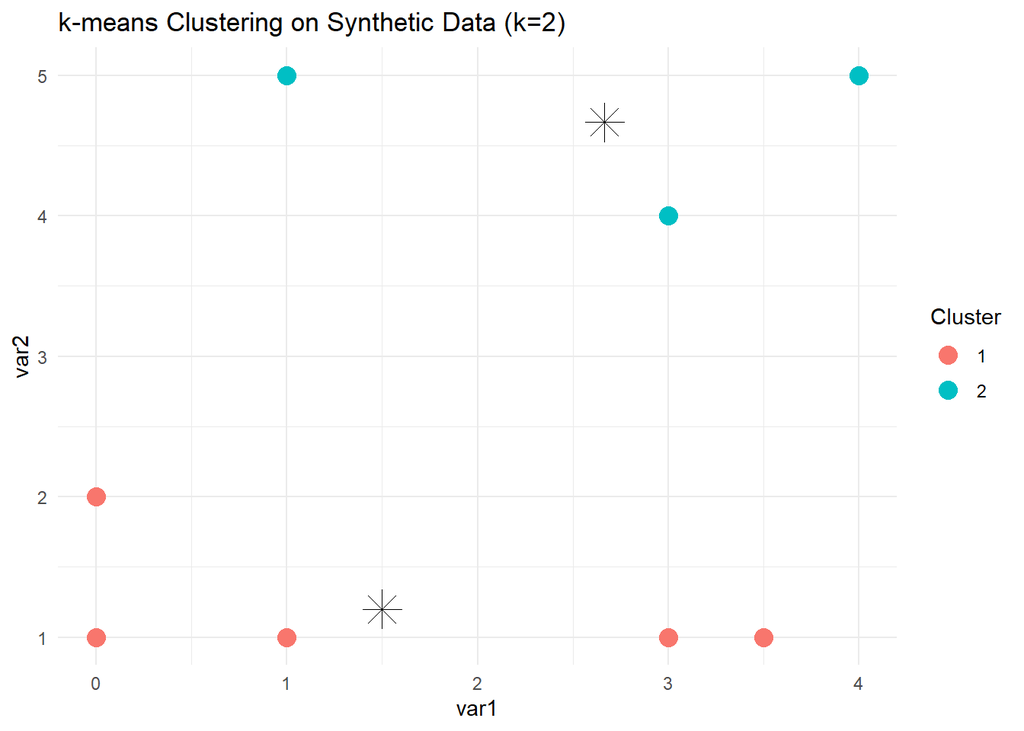

```r
library(ggplot2)

centers_df <- as.data.frame(kmeans_result$centers)

ggplot(synthetic_points, aes(x = var1, y = var2, color = factor(kmeans_result$cluster))) +
  geom_point(size = 4) +
  geom_point(
    data = centers_df,
    aes(x = var1, y = var2),
    color = "black",
    size = 6,
    shape = 8
  ) +
  labs(
    title = "k-means Clustering on Synthetic Data (k=2)",
    x = "var1",
    y = "var2",
    color = "Cluster"
  ) +
  theme_minimal()
```

# 3. High-Dimensional Station Dataset Study

## 3.1 Load the high-dimensional dataset

```r
load("data/high_dimensional_station_data.RData")
```

## 3.2 Descriptive analysis

### Inspect objects

```r
summary(velib)
```

```
##          Length Class      Mode
## data      181   data.frame list
## position    2   data.frame list
## dates     181   -none-     character
## bonus    1189   -none-     numeric
## names    1189   -none-     character
```

### Extract key tables

```r
X <- velib$data
position <- velib$position
```

### Dimensionality and completeness

```r
num_features <- ncol(X)
num_observations <- nrow(X)

cat("Number of features:", num_features, "\n")
```

```
## Number of features: 181
```

```r
cat("Number of observations:", num_observations, "\n")
```

```
## Number of observations: 1189
```

```r
cat("Missing values in X:", sum(is.na(X)), "\n")
```

```
## Missing values in X: 0
```

```r
cat("Missing values in position:", sum(is.na(position)), "\n")
```

```
## Missing values in position: 0
```

## 3.3 Dimensionality reduction with PCA

### Fit PCA

```r
out <- princomp(X)
```

### Scree plot

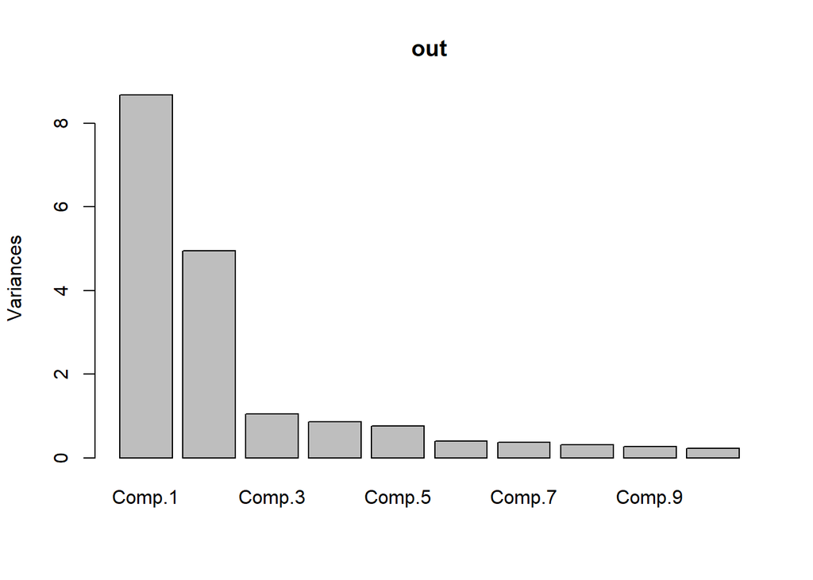

```r
screeplot(out)
```

### Cattell scree-test helper

```r
cattell <- function(x, thd = 0.1) {
  sc <- abs(diff(x))
  p <- length(x)
  d <- p - 1
  for (j in 1:(p - 2)) {
    if (prod(sc[(j + 1):length(sc)] < thd * max(sc))) {
      d <- j
      break
    }
  }
  d
}
```

### Select informative components

```r
d_cattell <- cattell(out$sdev)
d_cattell
```

```
## [1] 5
```

```r
d_star <- 5
Y <- predict(out)[, 1:d_star]
Y[1:10, ]
```

```
##           Comp.1     Comp.2     Comp.3     Comp.4     Comp.5
## 19117 -1.2040281 -2.2743248  0.3765529 -1.5113583 -0.7208404
## 17111  1.9966378 -4.2517544  0.0101666 -1.1582747 -0.6775315
## 6103   0.8860784  0.8326818  0.4468908 -1.0874062 -1.5082802
## 15042  0.6769466  3.7618830 -0.1271212  2.1575871  2.0098358
## 12003  2.1348525  2.8547899 -0.3616034 -0.8162485  1.2103656
## 13038 -0.3032946 -1.8535891  0.6121352 -0.9463538 -0.9531223
## 17041  0.6261200 -1.9621200  0.6162480 -0.1535873 -0.7289564
## 41203  0.4445372 -3.0455680  0.2804429  0.3607209 -0.4484349
## 43401  3.6341017  0.5580006  0.4430034  0.5438336  1.6503185
## 5015   0.9915129  0.7844612 -1.4838054 -0.1780015  3.4782944
```

### Pairwise component plots

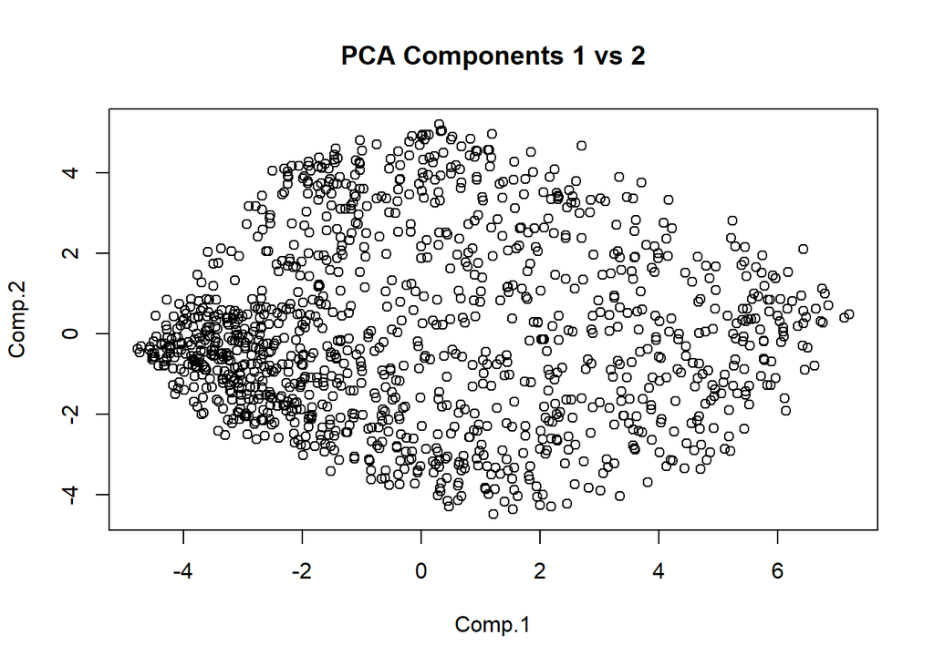

```r
plot(Y[, 1:2], main = "PCA Components 1 vs 2")
```

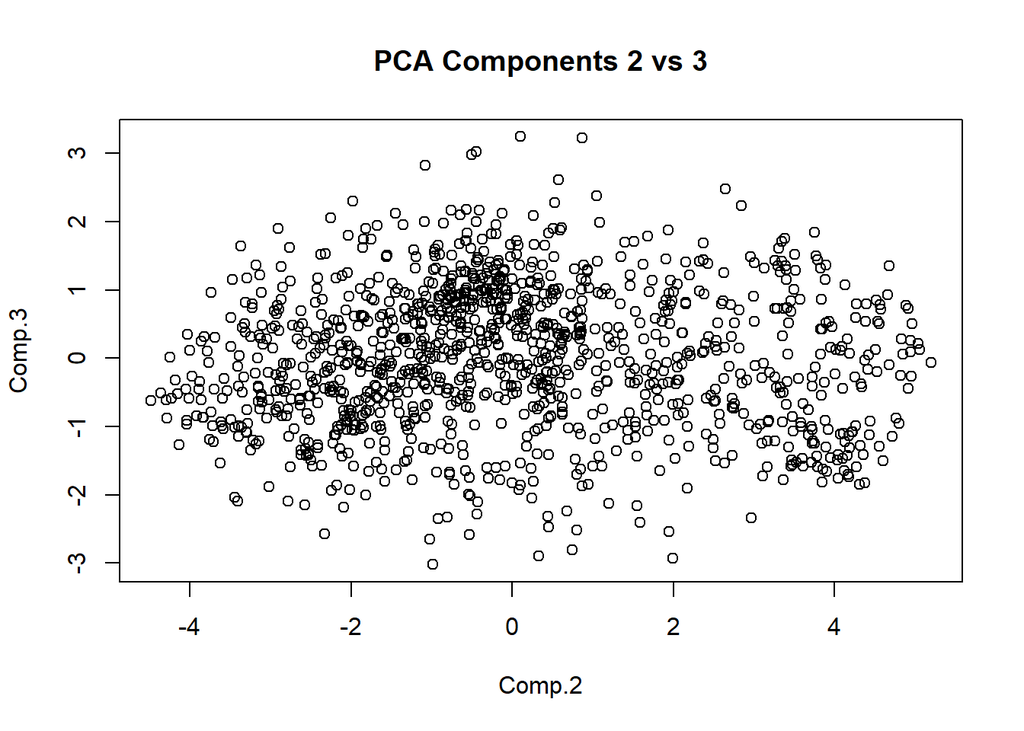

```r
plot(Y[, 2:3], main = "PCA Components 2 vs 3")
```

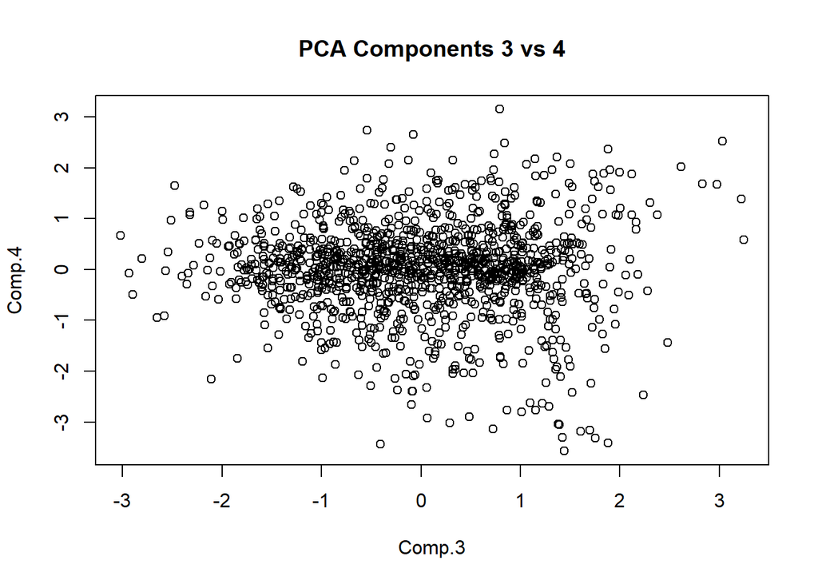

```r
plot(Y[, 3:4], main = "PCA Components 3 vs 4")
```

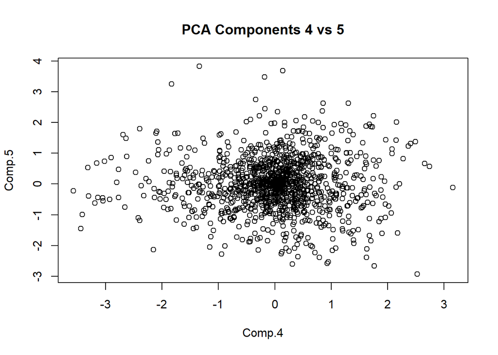

```r
plot(Y[, 4:5], main = "PCA Components 4 vs 5")
```

## 3.4 Clustering analysis

### 3.4.1 Hierarchical clustering

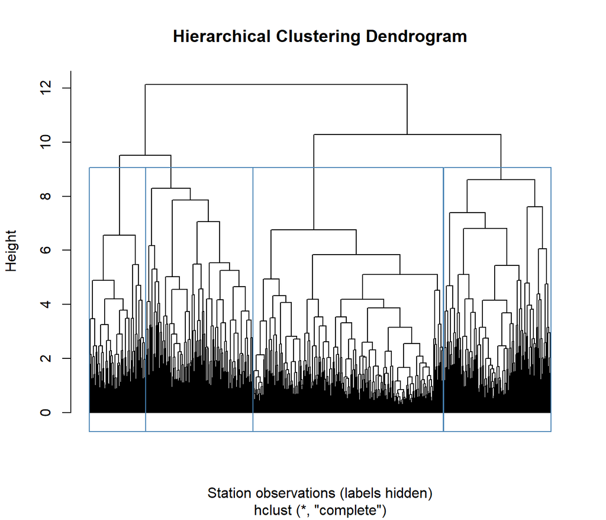

```r
out_hc <- hclust(dist(Y), method = "complete")
plot(
  out_hc,
  labels = FALSE,
  hang = -1,
  cex = 0.5,
  main = "Hierarchical Clustering Dendrogram",
  xlab = "Station observations (labels hidden)"
)
rect.hclust(out_hc, k = 4, border = "steelblue")
```

```r
hc_clust <- cutree(out_hc, k = 4)
```

```r
hc_map_data <- data.frame(
  longitude = position$longitude,
  latitude = position$latitude,
  cluster = factor(hc_clust)
)

paris_bbox <- list(
  xmin = min(hc_map_data$longitude) - 0.03,
  xmax = max(hc_map_data$longitude) + 0.03,
  ymin = min(hc_map_data$latitude) - 0.03,
  ymax = max(hc_map_data$latitude) + 0.03
)

render_interactive <- knitr::pandoc_to() %in% c("html", "html4", "html5")
if (render_interactive && requireNamespace("leaflet", quietly = TRUE)) {
  hc_palette <- leaflet::colorFactor("RdYlBu", domain = hc_map_data$cluster)
  leaflet::leaflet(hc_map_data) |>
    leaflet::addProviderTiles(leaflet::providers$CartoDB.Positron) |>
    leaflet::fitBounds(
      lng1 = paris_bbox$xmin,
      lat1 = paris_bbox$ymin,
      lng2 = paris_bbox$xmax,
      lat2 = paris_bbox$ymax
    ) |>
    leaflet::addCircleMarkers(
      lng = ~longitude,
      lat = ~latitude,
      radius = 3,
      color = ~hc_palette(cluster),
      stroke = FALSE,
      fillOpacity = 0.9,
      popup = ~paste("Cluster:", cluster)
    )
} else {
  basemap_df <- NULL
  if (requireNamespace("maps", quietly = TRUE)) {
    world_df <- ggplot2::map_data("world")
    basemap_df <- subset(
      world_df,
      long >= paris_bbox$xmin & long <= paris_bbox$xmax &
        lat >= paris_bbox$ymin & lat <= paris_bbox$ymax
    )
  }

  p_hc <- ggplot()
  if (!is.null(basemap_df) && nrow(basemap_df) > 0) {
    p_hc <- p_hc +
      geom_polygon(
        data = basemap_df,
        aes(x = long, y = lat, group = group),
        fill = "grey96",
        color = "grey70",
        linewidth = 0.2
      )
  }

  p_hc +
    geom_point(data = hc_map_data, aes(x = longitude, y = latitude, color = cluster), size = 1.8, alpha = 0.85) +
    coord_quickmap(
      xlim = c(paris_bbox$xmin, paris_bbox$xmax),
      ylim = c(paris_bbox$ymin, paris_bbox$ymax),
      expand = FALSE
    ) +
    labs(
      title = "Hierarchical Clusters on Paris Station Map",
      x = "Longitude",
      y = "Latitude",
      color = "Cluster"
    ) +
    theme_minimal()
}
```

[interactive chart not shown]

### 3.4.2 k-means clustering

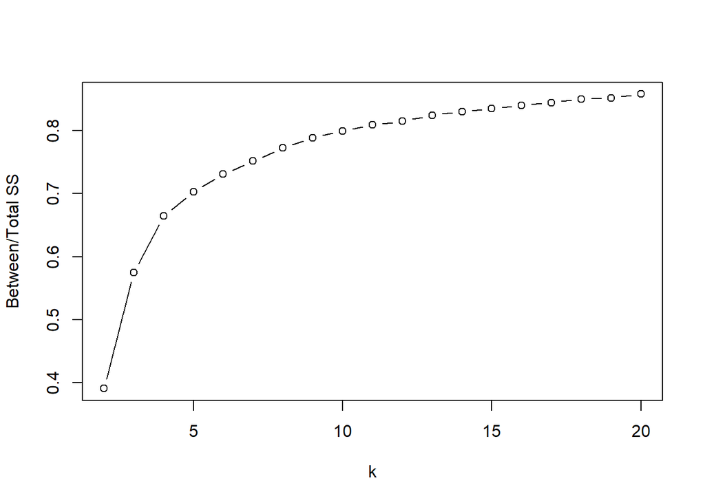

```r
k_max <- 20
J <- rep(NA, k_max)

for (k in 1:k_max) {
  out_k <- kmeans(Y, k, nstart = 10)
  J[k] <- out_k$betweenss / out_k$totss
}

plot(2:k_max, J[2:k_max], type = "b", xlab = "k", ylab = "Between/Total SS")
```

```r
out_km <- kmeans(Y, 5, nstart = 10)

km_map_data <- data.frame(
  longitude = position$longitude,
  latitude = position$latitude,
  cluster = factor(out_km$cluster)
)

render_interactive <- knitr::pandoc_to() %in% c("html", "html4", "html5")
if (render_interactive && requireNamespace("leaflet", quietly = TRUE)) {
  km_palette <- leaflet::colorFactor("RdYlBu", domain = km_map_data$cluster)
  leaflet::leaflet(km_map_data) |>
    leaflet::addProviderTiles(leaflet::providers$CartoDB.Positron) |>
    leaflet::fitBounds(
      lng1 = paris_bbox$xmin,
      lat1 = paris_bbox$ymin,
      lng2 = paris_bbox$xmax,
      lat2 = paris_bbox$ymax
    ) |>
    leaflet::addCircleMarkers(
      lng = ~longitude,
      lat = ~latitude,
      radius = 3,
      color = ~km_palette(cluster),
      stroke = FALSE,
      fillOpacity = 0.9,
      popup = ~paste("Cluster:", cluster)
    )
} else {
  p_km <- ggplot()
  if (!is.null(basemap_df) && nrow(basemap_df) > 0) {
    p_km <- p_km +
      geom_polygon(
        data = basemap_df,
        aes(x = long, y = lat, group = group),
        fill = "grey96",
        color = "grey70",
        linewidth = 0.2
      )
  }

  p_km +
    geom_point(data = km_map_data, aes(x = longitude, y = latitude, color = cluster), size = 1.8, alpha = 0.85) +
    coord_quickmap(
      xlim = c(paris_bbox$xmin, paris_bbox$xmax),
      ylim = c(paris_bbox$ymin, paris_bbox$ymax),
      expand = FALSE
    ) +
    labs(
      title = "k-means Clusters on Paris Station Map (k=5)",
      x = "Longitude",
      y = "Latitude",
      color = "Cluster"
    ) +
    theme_minimal()
}
```

[interactive chart not shown]

## 3.5 Method comparison

- Hierarchical clustering produces a four-cluster partition with broad regional structure.
- k-means indicates a plausible range near 4-6 clusters and isolates additional peripheral behavior.
- Both methods identify spatial grouping patterns, but they differ in how they split dense central regions.

## 3.6 Summary

- PCA reduces a high-dimensional feature space to five principal components for clustering.
- Hierarchical clustering and k-means provide complementary views of station segmentation.
- Cluster boundaries are partially overlapping, indicating nuanced structure rather than sharply separated groups.

# Contact

[Nicolas Len](https://www.linkedin.com/in/niclen/)  
Source code: [GitHub repository](https://github.com/nicolas-len/high-dimensional-clustering)